# Creating Images with R

A more pedantic version of XKCD 272

Austin Sarney asar897

```css
@import url('https://fonts.googleapis.com/css2?family=Cal+Sans&family=Micro+5&display=swap');
body {
  background: linear-gradient(90deg,rgb(187, 223, 250) 0%, rgb(51, 255, 169) 50%, rgb(187,223,250) 100%);
  background-size: 200% 200%;
  animation: backgroundAnimation 5s linear infinite alternate;
}

@keyframes backgroundAnimation {
  0% {background-position: 0% 50%}
  100% {background-position: 200% 50%}
}

h1, h2, h3, .author {
  font-family: "Cal Sans", sans-serif;
  padding: 10px;
}

.author {
  font-family: "Micro 5";
}

div:not(.main-container, .float, .figcaption) {
/* I thought it was strange that R Studio had Chrome's HTML inspector, but it turned out to be useful for getting those class names */
  background: rgba(255, 255, 255, 0.5);
  backdrop-filter: blur(10px);
  border-radius: 10px;
}

p {
  padding: 10px;
}
```

## Project requirements

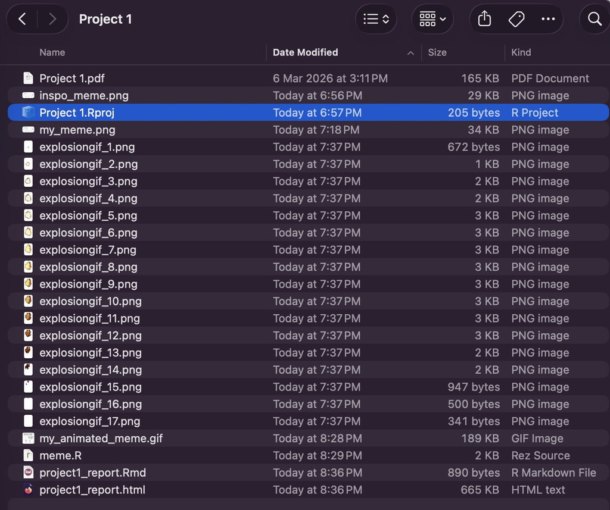

[my github repo](https://github.com/Austin-540/stats220)

## Inspo meme

[figure not shown]

xkcd 272

The key component of this meme is the proud linux user saying something in response to the employee asking about antiviruses. The meme uses multiple panels.

## My meme

[figure not shown]

To change the original comic, I covered up the text saying “I run linux” using a white box, then I added my own (more pedantic) text on top of it. I made this change to represent the complexities of the word “Linux” which are often brought up in discussions online. I have kept the base image the same.

## My animated meme

[figure not shown]

## Creativity

My project demonstrates creativity because:

- My animated meme adds another gif into one of the frames of my meme.
- To get each panel of the comic I used `image_crop()`, which was not in the lab.
- To put the explosion frames on top of panel 6 I used `image_composite()`, which was not in the lab.
- I used a gradient background with a simple animation and a white-blur background for each section using CSS made my report look more interesting.

## Learning reflection

I think from module 1, I thought that the most important idea we learned about was using vectors. I found them very useful when I was loading in all the frames from the explosion effect. If I hadn’t used a vector at that stage, I would have had to manually type out `explosion_frame_n` many times, duplicated a lot of code, and probably would have made a typo somewhere that would take me a long time to find. Vectors were useful for keeping multiple values inside one name, so that it can be used as a function input or iterated through in a for loop.

I am curious about how we can use our abilities to create images with R to create useful images that can share information, instead of just making memes. I think the tools we used for this assignment will probably be useful for future data visualization tasks, so I’m interested in seeing what else we can make.

## Appendix

Do not change, edit, or remove the `R` chunk included below.

If you are working within RStudio and within your Project1 RStudio project (check the top right-hand corner says “Project1”), then the code from the `meme.R` script will be displayed below.

This code needs to be visible for your project to be marked appropriately, as some of the criteria are based on this code being submitted.

```r
library(magick)

white_box <- image_blank(width=60, height=50, color="#EEEEEE")

meme <- image_read("inspo_meme.png") %>% #xkcd 272
  image_composite(white_box, offset="+210+25") %>% #Cover up the old text from the original comic by putting a white box over it
  image_annotate(text="I use GNU\n/Linux, or \nas I've \nrecently \ntaken to \ncalling it, \nGNU plus \nLinux---",
                 #Then add my text to it
                 size=15,
                 location="+210+25") #This bit lines it up with the box

image_write(meme, "my_meme.png")

# Now the animation section:

#Original comic frames
frame1 <- image_crop(meme, "195x180+0+0")
frame2 <- image_crop(meme, "87x180+195+0") #This one has my text in it
frame3 <- image_crop(meme, "219x180+420+0")
frame4 <- image_crop(meme, "224x140+0+190")
frame5 <- image_crop(meme, "238x140+233+190")
frame6 <- image_crop(meme, "148x140+483+190")

explosion_frames <- NULL
for (num in 3:17) {  #Honestly I should have just not bothered with a loop - it took a lot of debugging
  explosion_img <- image_read(paste(paste("explosiongif_", num, sep=""), ".png",  sep=""))
  img <- image_composite(frame6, explosion_img, offset = "+0+15") # Put the explosion frame onto the panel 6 background

  if (is.null(explosion_frames)) { # If this is the first explosion frame, create a list of type magick-image
    explosion_frames <- c(img)
  }
  explosion_frames <- c(explosion_frames, img) # Otherwise just add the frame to the list of explosion frames
}


frames <- c(frame1, frame1, frame1, frame1, frame1, frame1, frame1, frame1, frame1, frame1, frame1, frame2, frame2, frame2, frame2, frame2, frame2, frame2, frame2, frame2, frame2, frame2, frame2, frame2, frame3, frame3, frame4, frame4, frame5, frame5, frame6, explosion_frames)
# Duplicating frames with text on them so that you can actually have a chance of being able to read them

image_animate(frames, fps=5) %>%
  image_write("my_animated_meme.gif")
```